# Importance of Data Viz for Statistics

2026-07-24

## Motivation

## Why I am here?

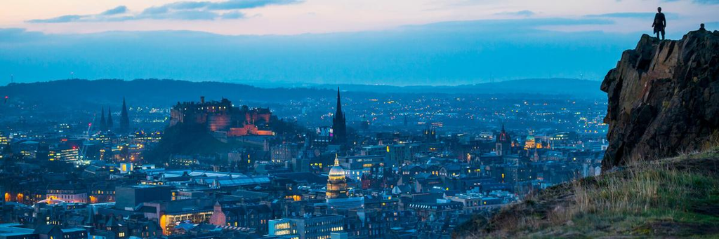

- To meet you and keep in touch
- Challenging myself with another talk
- being a part of big R community across the world

[About me](https://oevkaya.netlify.app/home)

## Data is the key

> The representation of numbers … should be directly proportional to the numerical quantities measured. — Edward Tufte 1983

## Data representation

- A dataset is a structured collection of data (observations or measurements (unprocessed or processed) of various data types: numbers, characters, factors, dates, etc.) associated with a unique field.
- Symbols that represent people, events, things or ideas etc. regarding the type that we are dealing with
- Humanities perspective:
  - “Almost nothing in the world is data. ‘Data’ is an abstraction we use to make certain kinds of inquiry possible.” [Natalia Cecire] – “Data is not a “given” but “taken actively” and constructed” [Johanna Drucker]
- Data Representation: The form in which data is stored and communicated, might differ in various ways (visualization, physicalization).

## Data Visualization

- As a part of the general data representation, data visualization is very important ingredient of any data analysis workflow.

> Data visualization plays a crucial role in transforming complex data into accessible and interpretable formats, including charts, graphs, scatter plots, or other visualization types (Gubala and Meloncon, 2022).

> “The representation and presentation of data to facilitate understanding”, framing comprehension as a dynamic process that involves perception, interpretation, and reasoning. (Kirk, 2016)
- For the abstraction, sketching your ideas on a paper or screen is a kind of start all the time. Or maybe in today’s computer-based era, inspiring from available examples.

## Two number examples

**In how many ways of representing/communicating two quantities? Such as 75, 37**

## So many

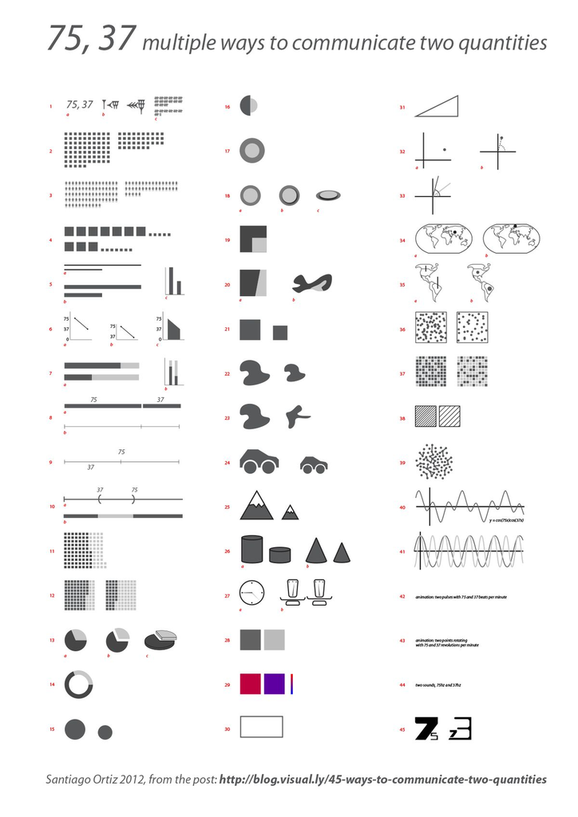

[Source:](https://www.namwkim.org/datavis/slides/2.%20Data%20Visualization-%20The%20Good,%20the%20Bad,%20the%20Weird.pdf)

## Historical Examples

[figure not shown]

[A Brief History of Data Visualization](https://www.researchgate.net/publication/226400313_A_Brief_History_of_Data_Visualization/figures?lo=1)

## Historical Examples

[figure not shown]

[William Playfair, the father of statistical graphics](https://flourish.studio/blog/masters-william-playfair-father-of-statistical-graphics/)

## Historical Examples

[figure not shown]

[Mapping a London Epidemic](https://education.nationalgeographic.org/resource/mapping-a-london-epidemic/)

## Historical Examples - Last but not least

[figure not shown]

[Florence Nightingale: Pioneer of Data Visualization](https://www.datacamp.com/blog/florence-nightingale-pioneer-of-data-visualization)

## Why DataViz is powerful

Visualization leverages the human visual system to facilitate;

- Understanding
- Discovery
- Decision making
- Communication
- Memory

**Our brain is capable of quick and efficient visual information processing at a pre-conscious level**

## Double Diamond Process

- **discover** : Understand the challenge/problem
- **define** : define the challenge/problem
- **develop** : explore different solutions
- **deliver** : testing different solutions

For data visualization task, we can imagine the nested model of the data visualization design process

- domain: Who are the target users?
- abstraction: What needs to be shown? Why should people look at it?
- (visual) encoding / interaction: What should be represented? How the representation can be manipulated
- format: How do we make it happen?

## About data visualisation guidelines

- **Structure of data** – attributes (types), data items or values
- **Visual marks** (geometries)/channels (controlling appearance of marks)
- Mapping data types to in different visual marks, channels
- **Expressiveness** - The visual encoding should express all of, and only, the information in the dataset attributes (matching channel and data characteristics)
- **Effectiveness** - The importance of the data attribute should be encoded with the most effective visual variable, in order to be noticeable

## Visual marks and channels

- Data variables (attributes) are encoded in different ways
- Thinking through appropriateness of different channels is the key in an iterative way
- Some example marks and channels

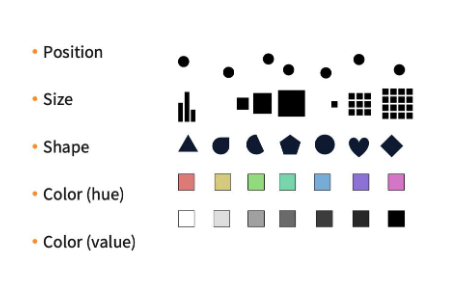

## Effectiveness & Expressiveness

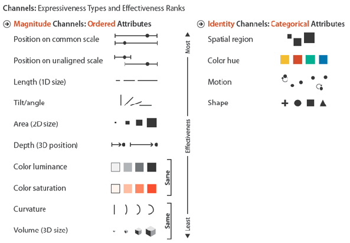

## Take a pause - What do you think?

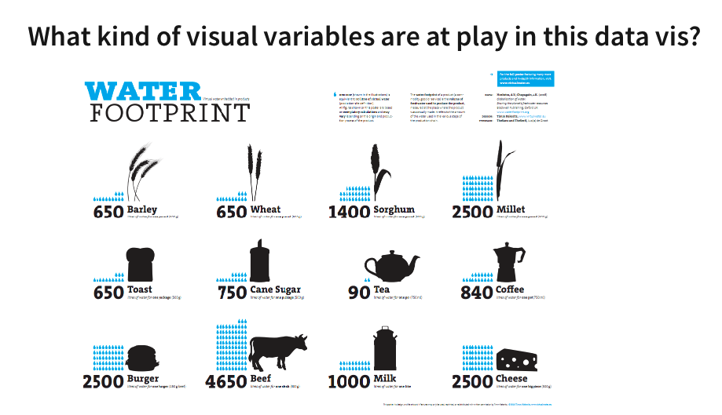

## What about this one

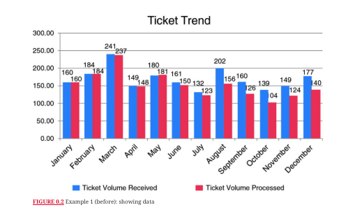

## Why Visualize - Worth to repeat

- See patterns, spot anomalies, generate questions. The purpose is to literally *see* what your data seems to say. Communicate findings clearly and persuasively.
- Start simple: summaries + visuals with EDA mindset. Always iterate to get a better version

Best final visual depends on;

- *data types*
- *context of the data*
- *tasks to perform*
- *questions to answer*
- *messages to deliver*

> *“The simple graph has brought more information to the data analyst’s mind than any other device.” — John Tukey*

## What is EDA?

- Exploratory data analysis (EDA) is the first step in **understanding** the main features and structures of a data set.
- Many statistical tools and techniques are used when performing EDA, but crucially they are **simple** to allow the data **speak** for itself.
- Tools that a data scientist may use are:
  - Data transformation/wrangling
  - Calculation of simple summary statistics (mean, median, variance, correlation, etc.)
  - Tabulation, Graphical or visual representations

> *“Although we often hear that data speak for themselves, their voices can be soft and sly.” — Mosteller et al. (1983)*

## Anscombe Data

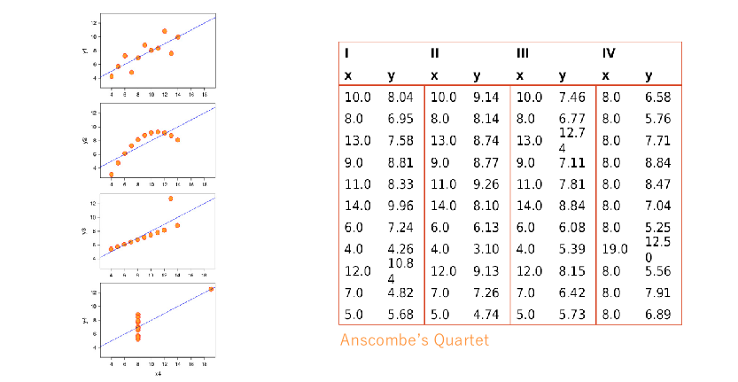

[Another example from our Data science course](https://uoeids.github.io/slides/w05-L10/w05-L10.html?panelset_002=statistics#7)

## Data Storytelling

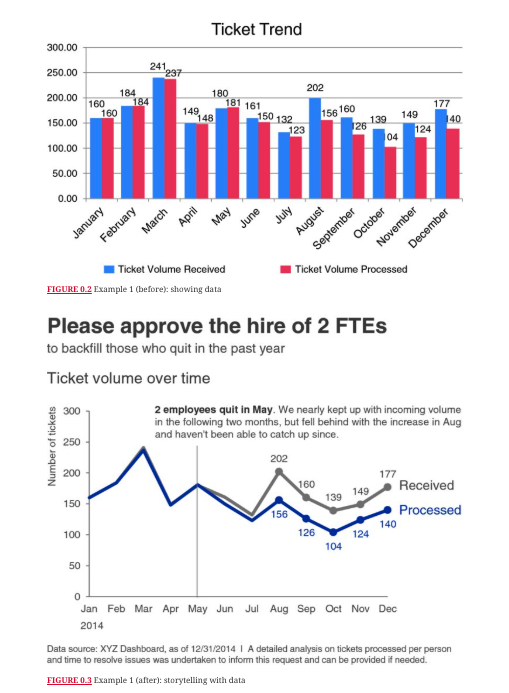

Source for Example: Storytelling with data a data visualization guide for business professionals Knaflic, Cole Nussbaumer, Wiley, 2015

## What we have via R programming?

> *“Data and information visualization is concerned with showing quantitative and qualitative information, so that a viewer can see patterns, trends or anomalies, constancy or variation, in ways that other forms—text and tables—do not allow” — Michael Friendly*

## ggplot2 \(\in\) tidyverse

- The most widely used R package for graphics.

[figure not shown]

- **ggplot2** is tidyverse’s data visualization package
- `gg` in “ggplot2” stands for *Grammar of Graphics* from the book by Leland Wilkinson

## Structure of creating a plot

- `ggplot()` is the main function in ggplot2
- Construct plots by *adding* (`+`) layers – **Not** the `%>%` pipe!
- Many types of geometries:
  - `geom_points()`, `geom_histogram()`, `geom_line()`, `geom_boxplot()`, etc.
- [ggplot2 cheat sheet](https://www.rstudio.com/resources/cheatsheets/)

## General Usage

```r
ggplot(data = [dataset], # Data
       # Aesthetics
       mapping = aes(x = [x-variable], y = [y-variable])) +
  # Geometries
   geom_[*]() +
  # ...
   other options/layers when you needed
```

## Example: Palmer Penguins

Measurements for penguin species, island in Palmer Archipelago, size (flipper length, body mass, bill dimensions), and sex.

```
## Rows: 344
## Columns: 8
## $ species           <fct> Adelie, Adelie, Adelie, Adelie, Adelie, Adelie, Adel…
## $ island            <fct> Torgersen, Torgersen, Torgersen, Torgersen, Torgerse…
## $ bill_length_mm    <dbl> 39.1, 39.5, 40.3, NA, 36.7, 39.3, 38.9, 39.2, 34.1, …
## $ bill_depth_mm     <dbl> 18.7, 17.4, 18.0, NA, 19.3, 20.6, 17.8, 19.6, 18.1, …
## $ flipper_length_mm <int> 181, 186, 195, NA, 193, 190, 181, 195, 193, 190, 186…
## $ body_mass_g       <int> 3750, 3800, 3250, NA, 3450, 3650, 3625, 4675, 3475, …
## $ sex               <fct> male, female, female, NA, female, male, female, male…
## $ year              <int> 2007, 2007, 2007, 2007, 2007, 2007, 2007, 2007, 2007…
```

## Example: Penguins dataset

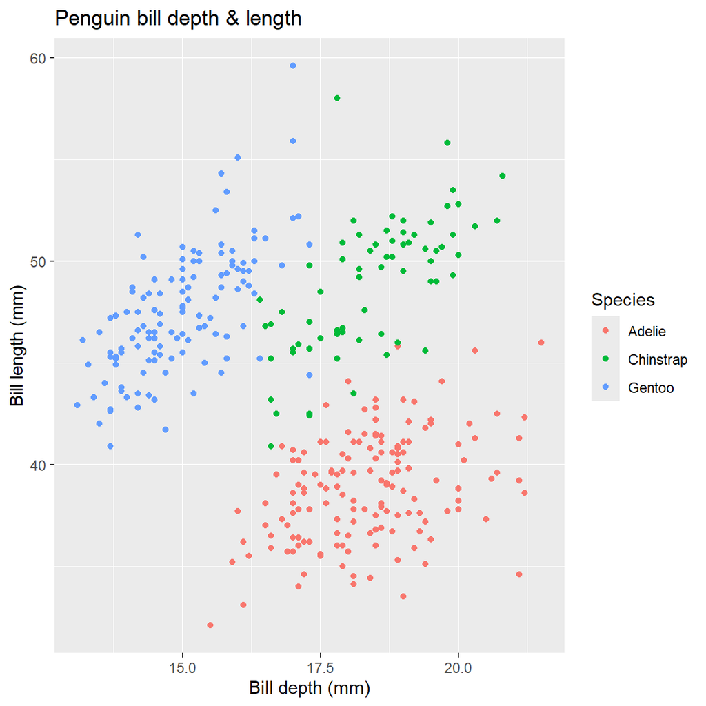

## Example: Penguins dataset

```r
penguins <- palmerpenguins::penguins
ggplot(data = penguins,
       mapping = aes(x = bill_depth_mm, y = bill_length_mm,
                     colour = species)) +
  geom_point() +
  labs(title = "Penguin bill depth & length",
       x = "Bill depth (mm)",
       y = "Bill length (mm)",
       colour = "Species")
```

## And iterate …

- Editing the aesthetic options: Point colour, size, shape, etc.
- Specify the limits of the co-ordinate axes to zoom in or out.
- Include additional descriptive information: sub-title, caption, data source citation, etc.
- Add other graphical information: line/curve of best fit, arrows, estimation intervals, etc.
- Faceting/panelling multiple plots into a grid.
- Changing the colour pallet that is more accessible for colour blindness.
- …

**However**, more is not necessarily good - there should be certain design choices and solid level of data understanding to decide what and how to visualize

## Understanding your data

- There are many types of data visualisation, each designed with a particular purpose.
- To determine which visualisation style is appropriate, consider:
  1. What are the properties of variables?
  2. How many variables to include (are necessary) in the data visualisation?
  3. What aspect of the data do you want to explore, investigate and communicate?

## Types of variables

- **Quantitative variables** are variables whose data are numerical values.
  - **Discrete variables** describes count data, typically non-negative integer values.  
    Eg, Number of IDS students or number of election votes.
  - **Continuous variables** are typically real-valued measurements, rounded to a specified number of decimal places or significant figures.  
    Eg, Penguin bill length, body mass and flipper length.

## Types of variables

- **Qualitative variable** are variables that are descriptive.
  - **Categorical (factor) variables** usually identify one option from a small set of cases.  
    Eg, Penguin breeds (Adelie, Chinstrap or Gentoo).
  - **Ordinal variables** are categorical variables that have a natural ordering.  
    Degree grades: First, upper-second, lower-second and third.

[From Data to Viz](https://www.data-to-viz.com/)

## Number of variables involved

- One variable (Univariate data analysis)
  - What is the *location*, *spread* and *shape* of the data?
  - Types of visualisations:**histogram**, **box plot**, **bar chart**, etc.
- Two variables (Bivariate data analysis)
  - Investigating the relationship between two variables. Positive/negative correlation? Linear or non-linear relationship?
  - Types of visualisations: **scatter plot**, **box plots**, **segmented bar plot**, etc.
- Three or more variables (Multivariate data analysis)
  - Investigating the relationship between many variables simultaneously.
  - Use of **colour**, **style** and **faceting** - be creative!

## Motivating Data Set: Bats

- Extracted from the [Atlantic Mammal Traits](https://esajournals.onlinelibrary.wiley.com/doi/10.1002/ecy.2106) survey on animal morphology.
- Data contains information about 4334 Neotropical fruit bats (*Aribeus*) from South America between 2010-2017.

```
## Rows: 4,334
## Columns: 6
## $ species   <chr> "Artibeus cinereus", "Artibeus cinereus", "Artibeus cinereus…
## $ body_mass <dbl> 12, 13, 11, 8, 13, 19, 12, 16, 11, 15, 18, 11, 11, 12, 14, 1…
## $ forearm   <dbl> 41.0, 38.6, 39.1, 39.2, 39.0, 43.0, 40.0, 41.0, 41.0, 40.5, …
## $ age       <chr> "adult", "adult", "adult", "adult", "adult", "adult", "juven…
## $ sex       <chr> "male", "female", "male", "male", "male", "female", "male", …
## $ year      <dbl> 2011, 2011, 2011, 2011, 2011, 2011, 2011, 2011, 2011, 2011, …
```

## Data Dictionary

| Variable | Description | Type |
| --- | --- | --- |
| `species` | Name of bat species | Categorical (5 cases) |
| `body_mass` | Body mass (in grams) | Numerical, continuous |
| `forearm` | Forearm length (in mm) | Numerical, continuous |
| `age` | Adult or Juvenile | Categorical (2 cases) |
| `sex` | Female or Male | Categorical (2 cases) |
| `year` | Year of measurement | Numerical, discrete |

## Histogram by default

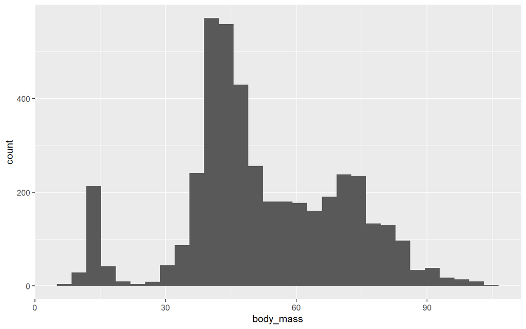

## Histogram by certain modifications

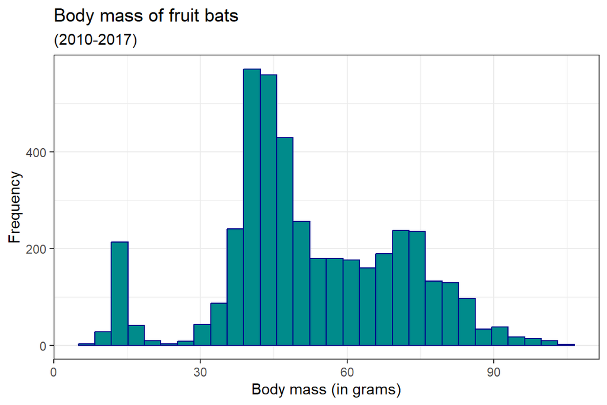

## Density plot

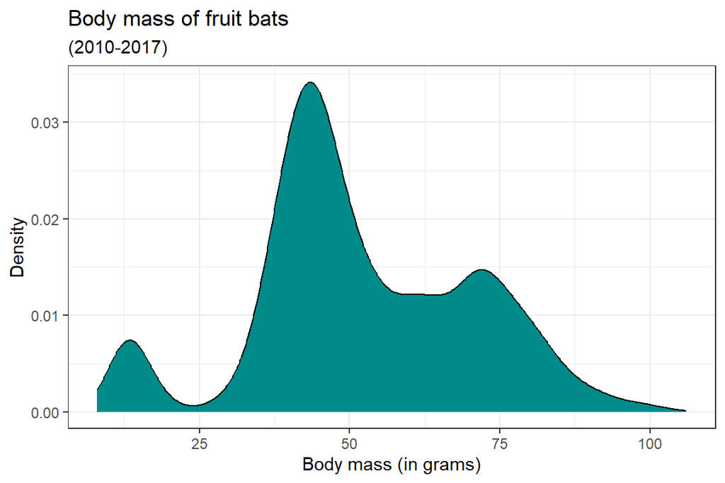

## Box plot

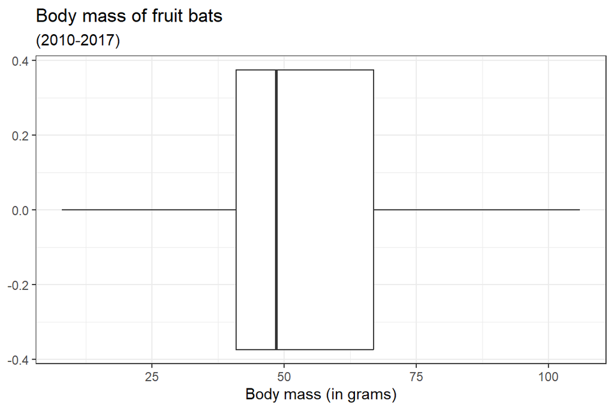

## Adding a categorical variable via aesthetics

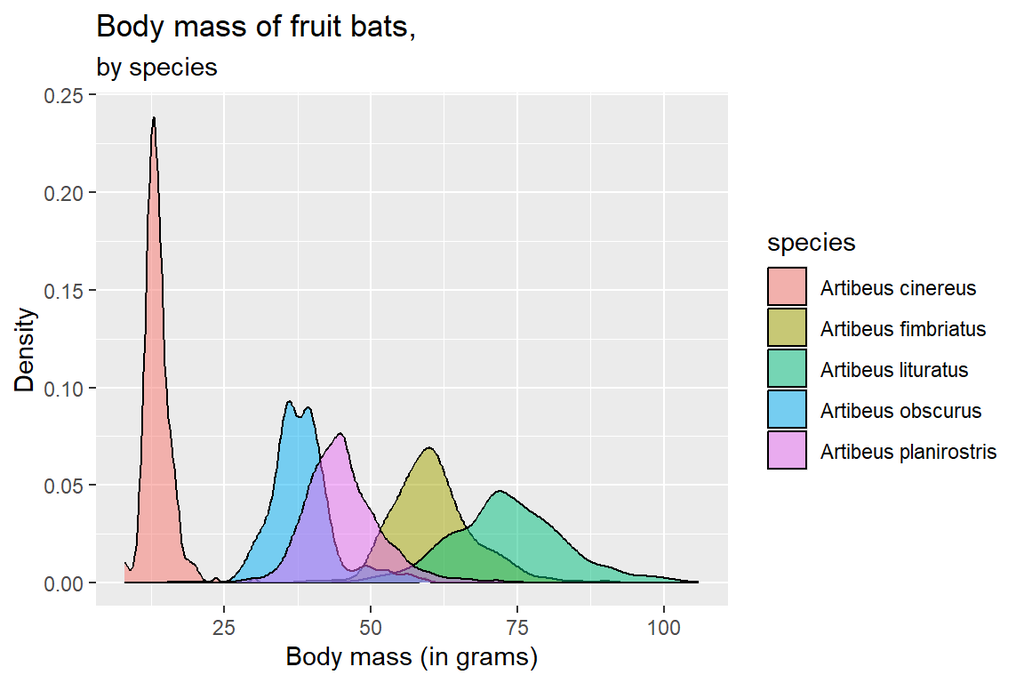

## Via facetings

As a 2x2 setting

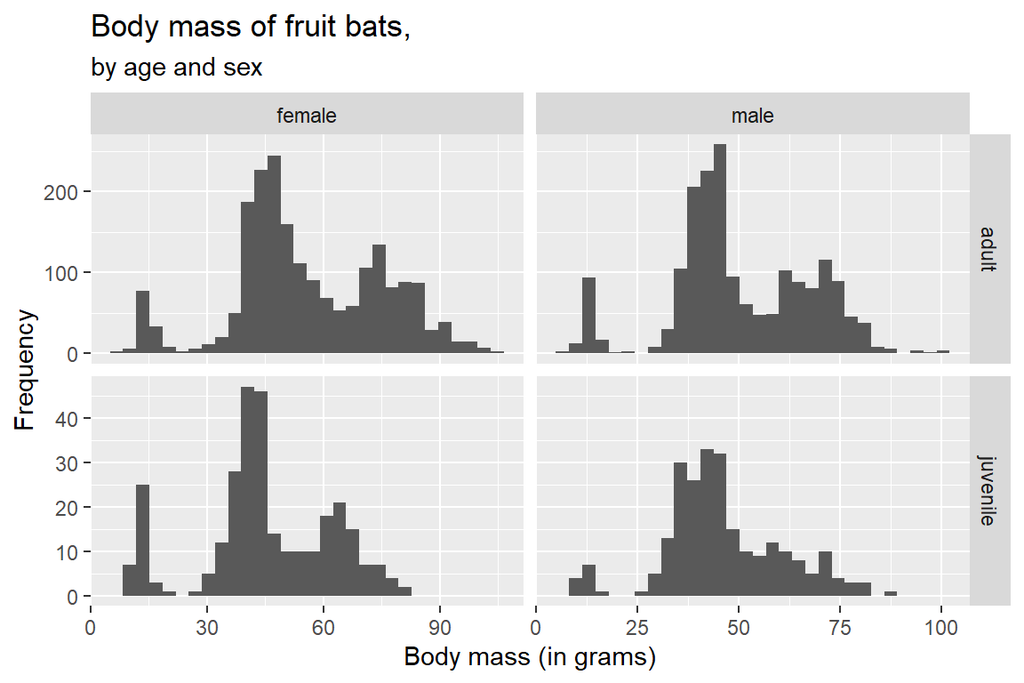

## Data visualisation gallery

- `ggplot2` is used to create a wide variety of data visualisation styles. It has many customisation tools to support your communication.
- Use `ggplot2` manual pages (and online searches) to support your creation.
- Specific starting point would be [R Graph gallery](https://r-graph-gallery.com/)
- **But**, excessive customisation can be distracting.
- In general, there are various resources to explore in R ecosystem.

## Each data or work requires its own data viz type and style

## From my Covid19 work

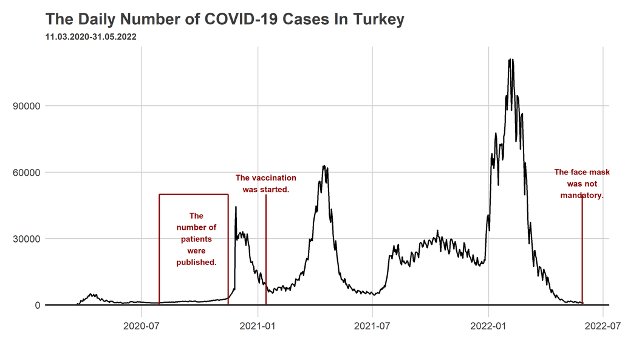

[Leveraging Ensemble and Hybrid Forecasting Tools to Increase Accuracy: Turkey COVID-19 Case Study](https://link.springer.com/article/10.1007/s42979-025-03658-2)

## GenAI survey paper

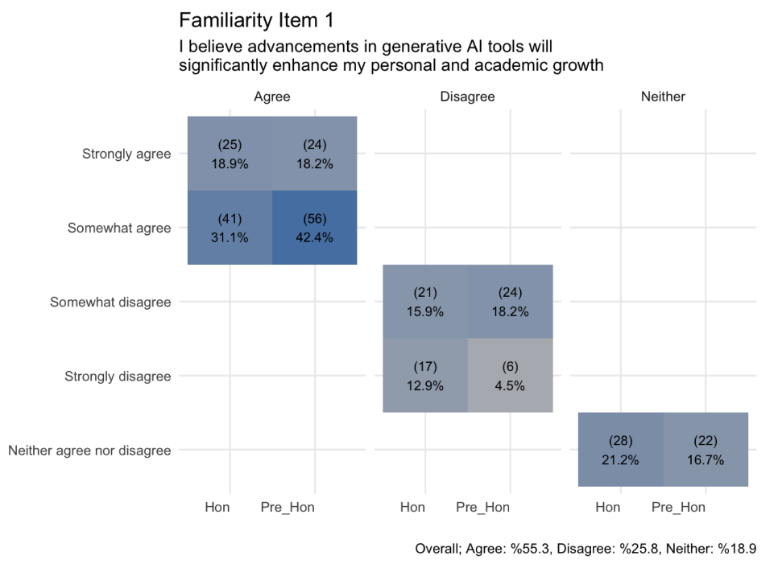

[Mathematics Students’ Adoption and Perceptions of Generative AI tools -Results from a Survey](https://github.com/oevkaya/GenAI-Edi-Survey)

## Scottish Deprivation data

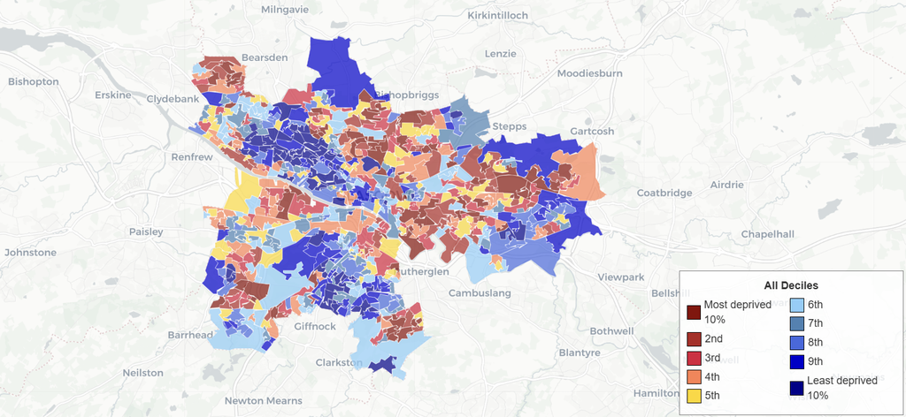

[Cluster-specific ranking and variable importance for Scottish regional deprivation via vine mixtures](https://arxiv.org/abs/2508.04533)

## From my student projects

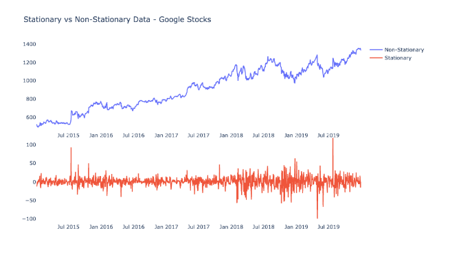

## From my student projects

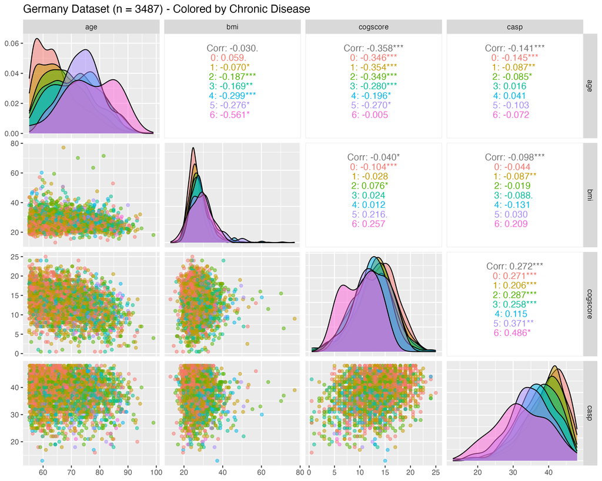

UG project: Clustering Dementia Characteristics Using Vine Copula Mixture Models

## From my student projects

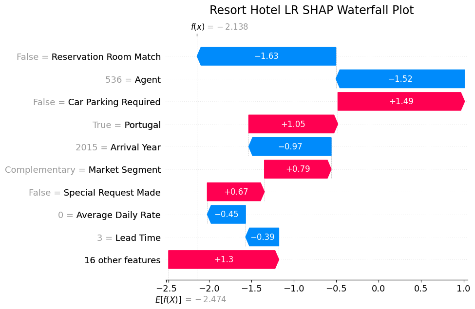

[Machine Learning Meets Hospitality: Explainable AI in Hotel Booking Cancellations](https://hotel-booking-dashboard.streamlit.app/)

## From my student projects - ERASMUS+ Internship

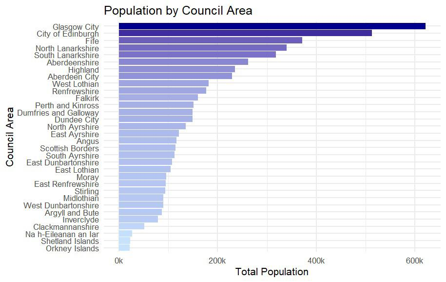

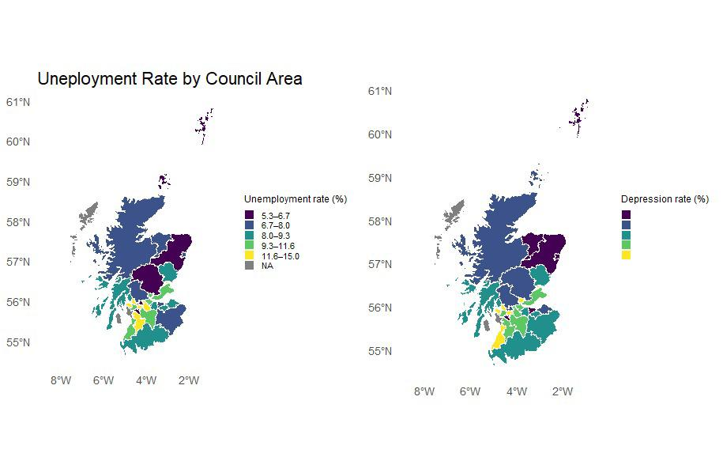

## From my student projects - ERASMUS+ Internship

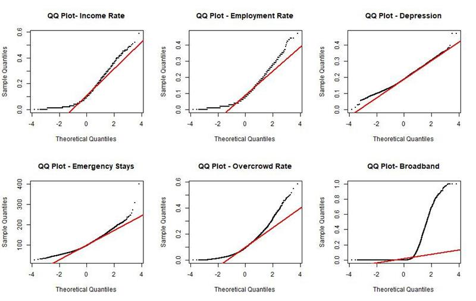

## From my student projects - 25-26

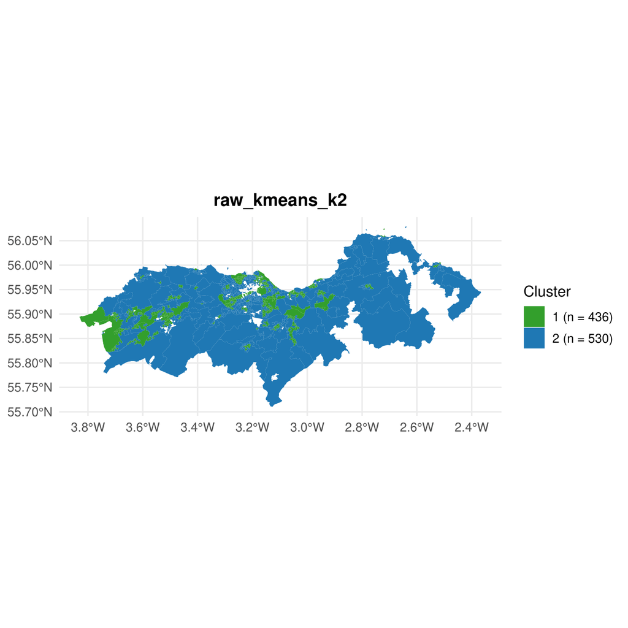

UG project: Exploiting clustering with vine copulas to examie the Scottish Index of Multiple Deprivation (SIMD) 2020